# SARFRAZ_HW1_310

Hussain Sarfraz

1/15/2022

# Question 1

## Part A

I set my working directory and then used the **read_csv()** function to store in the **AlabamaCourt.csv** dataset into the object **alabama.court**.

```r
setwd("C:/Users/hussainsarfraz/Desktop/DATA 310")
alabama.court <-  read_csv('AlabamaCourt.csv')
```

## Part B

I used the **mutate()** function to create the two new variables **black** and **amountremain**.

The variable **black** lets me know if a person convicted of a crime is African-American. I check this by using a **ifelse()** function which would write the value **1** if a persons race equals **B** and if the persons race is not equal to **B** then the value to indicate that would be **zero**.

```r
alabama.court <- alabama.court %>%
  mutate(black = ifelse((race=='B'), 1, 0),
         amountremain = amountpaid - amountdue)
```

## Part C

For this question I changed the R markdown script that I am going to use to display the stargazer tables. Instead of writing **{r}** (in the beginning of the R markdown R script) I wrote **{r,results=‘asis’}**. I did this because I changed my stargazer table type to **html** so the stargazer tables can be displayed properly in R markdown (such as the titles).

I used the **subset()** function to filter out the specific rows that I needed from the **alabama.court** dataset.

- I first converted the **alabama.court** dataset from a **tibble** to a **data frame** using the **as.data.frame()** function. I did this because stargazer can only make tables of **data frames**
- I used the **race** variable to filter out the people who were African American and non-African Americans.
- I used the **select()** function to pick the specific columns that I want to display in the stargazer table.

I then made my stargazer table type to **html** since my R markdown file was being displayed in **html**. I then re-named the variable names from the **alabama.court** dataset to names that would make sense to someone if it was their first time viewing the table (I did this through **covariate.labels =**. I also set the display of digits for each number to only go to two decimal places since I did not want the values in the table to be hard to read (did this through **digits =** ).

```r
### African Americans
stargazer(subset(as.data.frame(alabama.court),
                 alabama.court$race == 'B',
                 select = c(amountremain,amountdue,amountpaid)),
          type = 'html',
          title = "Legal Financial Obligations (LFOs) in Alabama Court Cases for African Americans",
          covariate.labels = c('Remaining LFOs','LFOs Assesed','LFOs Paid to Date'),
          digits = 2)
```

**Legal Financial Obligations (LFOs) in Alabama Court Cases for African Americans**

| Statistic | N | Mean | St. Dev. | Min | Pctl(25) | Pctl(75) | Max |
| --- | --- | --- | --- | --- | --- | --- | --- |
| Remaining LFOs | 1,366 | -3,568.94 | 10,222.09 | -161,076 | -3,261 | -445.9 | 0 |
| LFOs Assesed | 1,366 | 4,040.68 | 10,339.03 | 0 | 786.0 | 3,674.8 | 163,642 |
| LFOs Paid to Date | 1,366 | 471.74 | 1,095.38 | 0 | 0 | 510.8 | 20,366 |

```r
### non-African Americans
stargazer(subset(as.data.frame(alabama.court),
                 alabama.court$race != 'B',
                 select = c(amountremain,amountdue,amountpaid)),
          type = 'html',
          title = "Legal Financial Obligations (LFOs) in Alabama Court Cases for non-African Americans",
          covariate.labels = c('Remaining LFOs','LFOs Assesed','LFOs Paid to Date'),
          digits = 2)
```

**Legal Financial Obligations (LFOs) in Alabama Court Cases for non-African Americans**

| Statistic | N | Mean | St. Dev. | Min | Pctl(25) | Pctl(75) | Max |
| --- | --- | --- | --- | --- | --- | --- | --- |
| Remaining LFOs | 1,560 | -3,582.68 | 12,659.16 | -251,650 | -2,961.5 | 0 | 0 |
| LFOs Assesed | 1,560 | 4,398.81 | 12,997.50 | 0 | 857.5 | 3,683.5 | 262,245 |
| LFOs Paid to Date | 1,560 | 816.13 | 1,834.35 | 0 | 0 | 1,127.2 | 40,328 |

```r
### Checking if dataset is tibble |output:TRUE
#is_tibble(alabama.court)

### checking total number of rows |output:2926
#nrow(alabama.court)

### double checking row number |output:1366
# subset(as.data.frame(alabama.court),
#        alabama.court$race == 'B',
#        select = c(amountremain,amountdue,amountpaid)) %>%
#   nrow()

### double checking row number (2926-1366=1560) |output:1560
# subset(as.data.frame(alabama.court),
#        alabama.court$race != 'B',
#        select = c(amountremain,amountdue,amountpaid)) %>%
#   nrow()
```

## Part D

When I created my graphs for this question I noticed that all the values in the x-axis were is scientific notation so I wrote **options(scipen=999)** to make sure all my graphs display numbers instead of scientific notation.

```r
# To remove the scientific notation in the graphs
options(scipen=999)
```

I have divided my graphs with each heading, but most of the code that I wrote for each graph is the same and nothing was changed drastically (just the names of titles or axis labels). I did this because I needed to create three graphs which each represented one variable (**amountremain, amountdue, and amountpaid**). So most of what I explain in the first graph is too be applied to the other graphs as a explanation to how I constructed them.

> Graph which shows number of LFOs Remaining for Convicted Criminals (African Americans and non-African Americans) (Graph 1)

When creating this kernel density plot I had to make sure to create a new variable called **amountremain1** which basically added **one** to all the values in the variable **amountremain**. I did this because I was going to use the **log scale** to stretch out my graph since my graph without the log scale made it hard to see some points (this is because the graphs outliers would not make the graph clear.)

- I have also added **one** to the other graphs as well for the respective variables

I then used **group =** inside **aes()** to let R know that the variables in the **black** variable are supposed to be grouped. After I made this change I noticed that my graphs color scheme was displayed as a gradient and I did not want that since the values under the **black** variable were categorical. Because of this I used the **as.factor()** function in **fill =** to let R know that the values in the **black** variable need to be grouped in separate boxes and should not be displayed as a gradient.

I also noticed that the lines were not colored in this graph and the space underneth the curve was colored. Because of this I decided to lighten the color so the overlapped line portions can be seen for easier analysis (I did this through **alpha=0.3**).

I then used **scale_fill_manual()** to make my legend for comprehensive and for it to make more sense. **NOTE:** before I used **scale_fill_manual()** I could see what number represented each color and from there I knew what label to give each box.

I then used **scale_x_continuous()** to implement the **log scale** and write down the values that I want to diaply on the x-axis.

The following functions were used for additional formatting:

- **xlab()** : Used to change x-axis label
- **ylab()** : Used to change y-axis label
- **ggtitle()** : Used to add a graph title
- **theme_bw()** : Used to add a thin black frame around the graph
- **theme(plot.title = element_text(hjust = 0.5))** : Used to put the title in the middle

[figure not shown]

[figure not shown]

This is a screenshot of the graph. For some reason the whole graph is displayed on my R console but the whole thing is not displayed through R markdown which is why I included this screenshot

```r
alabama.court %>%
  mutate(amountremain1 = amountremain + 1) %>%
  ggplot(.) +
  geom_density(aes(x = amountremain1,
                       group=black,
                       fill=as.factor(black)),
               alpha=0.3) +
  scale_fill_manual(values = c('red','blue'),
                    name="Race Key",
                    labels=c("Non-African Americans",
                             "African Americans")) +
  scale_x_continuous( trans='log10',
                      breaks = c(1,10,100,1000,10000,100000)) +
  xlab("$ of LFOs Remaining") +
  ylab('Number of Cases') +
  ggtitle("$ of LFOs Remaining for Convicted Criminals") +
  theme_bw() +
  theme(plot.title = element_text(hjust = 0.5))
```

> Graph which shows number of LFOs Assesed for Convicted Criminals (African Americans and non-African Americans) (Graph 2)

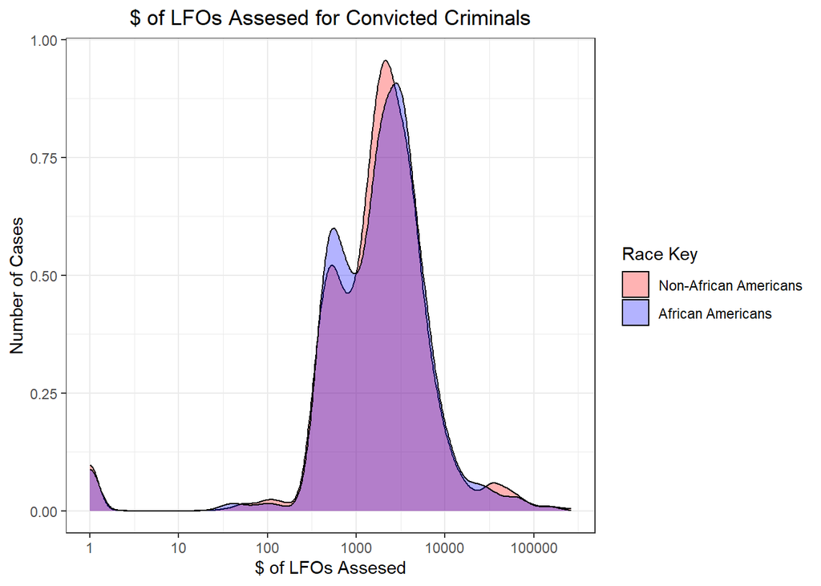

```r
alabama.court %>%
  mutate(amountdue1 = amountdue + 1) %>%
  ggplot(.) +
  geom_density(aes(x = amountdue1,
                       group=black,
                       fill=as.factor(black)),
               alpha=0.3) +
  scale_fill_manual(values = c('red','blue'),
                    name="Race Key",
                    labels=c("Non-African Americans",
                             "African Americans")) +
  scale_x_continuous( trans='log10',
                      breaks = c(1,10,100,1000,10000,100000)) +
  xlab("$ of LFOs Assesed") +
  ylab('Number of Cases') +
  ggtitle("$ of LFOs Assesed for Convicted Criminals") +
  theme_bw() +
  theme(plot.title = element_text(hjust = 0.5))
```

> Graph which shows number of LFOs Paid to Date for Convicted Criminals (African Americans and non-African Americans) (Graph 3)

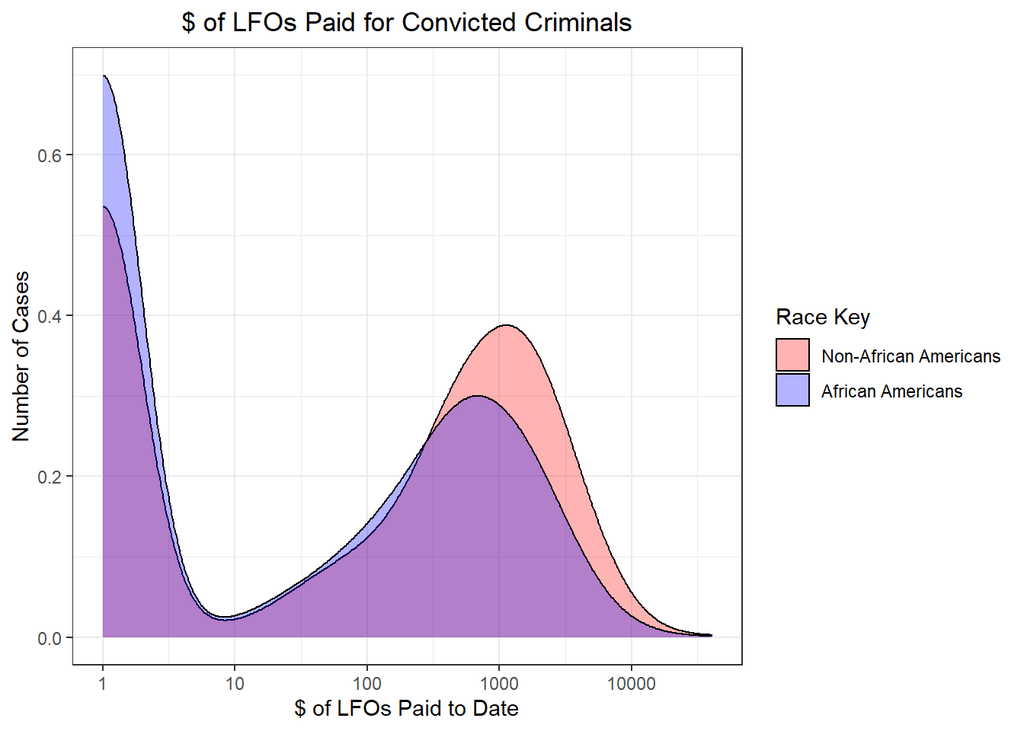

```r
alabama.court %>%
  mutate(amountpaid1 = amountpaid + 1) %>%
  ggplot(.) +
  geom_density(aes(x = amountpaid1,
                       group=black,
                      fill=as.factor(black)),
               alpha=0.3) +
  scale_fill_manual(values = c('red','blue'),
                    name="Race Key",
                    labels=c("Non-African Americans",
                             "African Americans")) +
  scale_x_continuous( trans='log10',
                      breaks = c(1,10,100,1000,10000,100000)) +
  xlab("$ of LFOs Paid to Date") +
  ylab('Number of Cases') +
  ggtitle("$ of LFOs Paid for Convicted Criminals") +
  theme_bw() +
  theme(plot.title = element_text(hjust = 0.5))
```

## Part E

According to my analysis (after looking at the graphs and stargazer table) I believe there are no racial differences between how much **LFOs are assessed** to African Americans and non-African Americans.

I have explained my analysis below in greater detail. I first talk about my interpretation of the kernel density plots that I created then I go n to analyse the stargazer tables that I made.

> The graph of LFOs remaning for convicted criminals (Graph 1)

> The graph of LFOs assessed to convicted criminals (Graph 2)

When I looked at this graph I was able to strengthen my second hypothesis because I noticed that the LFOs assessed to both African Americans and non-African Americans are quite similar. In fact, a certain group of non-African Americans were assigned to pay more LFOs to the State of Alabama (this overlap can be seen around **$1000 to $5000**). This observation debunks my first hypothesis that African American convicted criminals are given greater amounts of LFOs which makes it harder for them to pay them off.

> The graph of LFOs paid to date by convicted criminals (Graph 3)

Seeing this graph strengthened my second hypothesis since I saw that a greater amount of **non-African Americans** paid a certain amount of their LFOs as compared to African Americans (this overlap can be seen around **$500 to $15000**). This means that African Americans are having a hard time to find job opportunities or ways to pay back their LFOs. This could be because African Americans have a hard time finding a job due to their race whereas it might be easier for non-African Americans to find a job and pay off their LFOs.

> Stargazer table of LFOs for African Americans and non-African Americans

The stargazer tables for African Americans and non-African Americans supported my second hypothesis since I noticed these things:

**Mean**

# Question 3

```r
college.basketball <- read_csv('CollegeBasketball.csv')
```

## Part A

> The mean of the absolute value of variable “predicted.diff_result” (difference of predicted and actual performance) is 8.26971

**NOTE**: For **parts A and C** I used similar logic in creating my code

I calculated the mean by first converting all the values in the **predicted.diff_result** to positive numbers (I did this through the **abs()** function). The mean lets me know a average amount of how far the datasets points are from the line of regression.

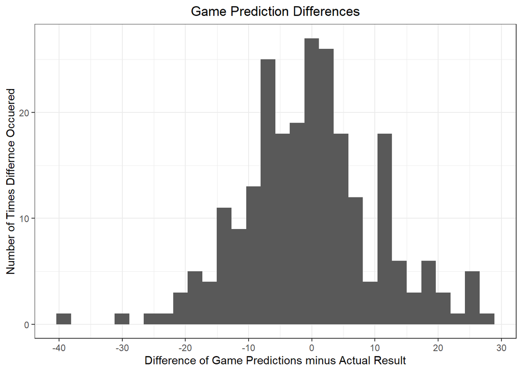

```r
college.basketball <- college.basketball %>%
  mutate(predicted.diff_result = PredictedDifference - ActualDifference)

ggplot(data = college.basketball) +
  geom_histogram(aes(x = predicted.diff_result)) +
  scale_x_continuous(breaks = c(-40,-30,-20,-10,0,10,20,30,40)) +
  xlab("Difference of Game Predictions minus Actual Result") +
  ylab('Number of Times Differnce Occuered') +
  theme_bw() +
  ggtitle('Game Prediction Differences') +
  theme(plot.title = element_text(hjust = 0.5))
```

```r
# how far points are from line of regression
mean(abs(college.basketball$predicted.diff_result))
```

```
## [1] 8.26971
```

## Part B

> My Probability Results:

| Probability | Decimal Result (can be % if multiplied by 100) |
| --- | --- |
| P(W) | 0.5020747 |
| P(E) | 0.02904564 |
| P(L) | 0.4688797 |

For the answers to **part B and D** I used similar logic in assigning values to the new variables.

- values under the **predicted.diff_result** and **predicted.point_result** variables that are **negative** actually mean that the basketball game was won by more points than expected or the game performance (by the favorites) was better than expected. This is because the gamblers expectations/predictions would be lower than the actual results which is why a negative value represents something positive for the favorites
- values under the **predicted.diff_result** and **predicted.point_result** variables that equal to **zero** actually mean that the basketball game prediction of performance and points actually **met** the gamblers expectations. This is because the prediction number and actual result is the same.
- values under the **predicted.diff_result** and **predicted.point_result** variables that are **positive** actually mean that the basketball game prediction of performance and points actually **did not meet** the gamblers expectations. This means that the favorites lost the game or performed lower than expected. This is because the prediction number is higher than the and actual result.

For both, **part B and D** I calculated the mean to find the probability of the variables since to calculate the mean you need to add all values and divide by the total amount of rows. Also, the newly made variables had ones and zeros in them which meant that calculating the mean would let me know how many times these instances occured which is what I wanted to find out.

```r
college.basketball <- college.basketball %>%
  mutate(W = ifelse((predicted.diff_result <  0),1,0),
         E = ifelse((predicted.diff_result == 0),1,0),
         L = ifelse((predicted.diff_result >  0),1,0))

#P(W)
mean(college.basketball$W)
```

```
## [1] 0.5020747
```

```r
#P(E)
mean(college.basketball$E)
```

```
## [1] 0.02904564
```

```r
#P(L)
mean(college.basketball$L)
```

```
## [1] 0.4688797
```

## Part C

> The mean of the absolute value of variable “predicted.point_result” (difference of predicted and actual points) is 13.50622

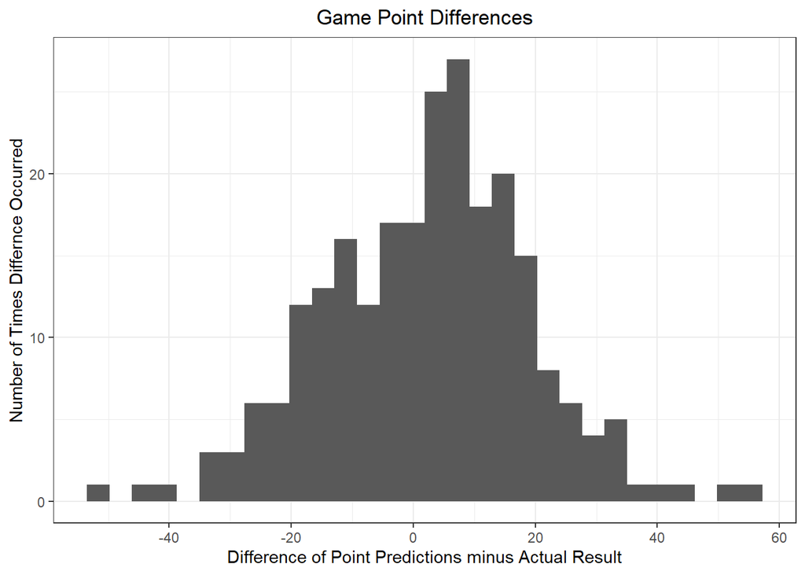

```r
college.basketball <- college.basketball %>%
  mutate(predicted.point_result = PredictedPoints - ActualPoints)

ggplot(data = college.basketball) +
  geom_histogram(aes(x = predicted.point_result)) +
  scale_x_continuous(breaks = c(-40,-20,0,20,40,60)) +
  xlab("Difference of Point Predictions minus Actual Result") +
  ylab('Number of Times Differnce Occurred') +
  theme_bw() +
  ggtitle('Game Point Differences') +
  theme(plot.title = element_text(hjust = 0.5))
```

```r
# how far points are from line of regression
mean(abs(college.basketball$predicted.point_result))
```

```
## [1] 13.50622
```

## Part D

> My Probability Results:

| Probability | Decimal Result (can be % if multiplied by 100) |
| --- | --- |
| P(M) | 0.3858921 |
| P(T) | 0.04149378 |
| P(F) | 0.5726141 |

```r
college.basketball <- college.basketball %>%
  mutate( M =  ifelse((predicted.point_result <  0),1,0),
         'T' = ifelse((predicted.point_result == 0),1,0),
         'F' = ifelse((predicted.point_result >  0),1,0))

#P(M)
mean(college.basketball$M)
```

```
## [1] 0.3858921
```

```r
#P(T)
mean(college.basketball$'T')
```

```
## [1] 0.04149378
```

```r
#P(F)
mean(college.basketball$'F')
```

```
## [1] 0.5726141
```

## Part E

> My Probability Results:

[output not shown]

**NOTE**: I got these results by using this formula

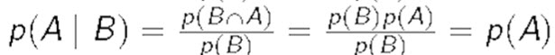

```r
#P(W | M)
(mean(college.basketball$M)*mean(college.basketball$W))/mean(college.basketball$M)
```

```
## [1] 0.5020747
```

```r
#P(L | M)
(mean(college.basketball$M)*mean(college.basketball$L))/mean(college.basketball$M)
```

```
## [1] 0.4688797
```

```r
#P(W | F)
(mean(college.basketball$'F')*mean(college.basketball$W))/mean(college.basketball$'F')
```

```
## [1] 0.5020747
```

```r
#P(L | F)
(mean(college.basketball$'F')*mean(college.basketball$L))/mean(college.basketball$'F')
```

```
## [1] 0.4688797
```

```r
# #P(W)
# mean(college.basketball$W)
# #P(L)
# mean(college.basketball$L)
#
# #P(M)
# mean(college.basketball$M)
# #P(F)
# mean(college.basketball$'F')
```

## Part F

The evidence that I have gathered **is consistent** with the theory mentioned above since the probability of **P(L | M) and P(W | F)** were close to each other (there was probably a small difference of **0.04**).

- M is the variable that represents when the favorite team had more combined points than expected and
- L is the variable that represents when the favorite team won the game by fewer points than expected or lost.